# Does Airbnb Cause Rent Prices to Increase?

SaiArvind Ganganapalle

## Introduction

### Motivation

In [season 2 episode 6](https://www.imdb.com/title/tt4498796/?ref_=ttep_ep6) of Netflix’s [*Unbreakable Kimmy Schmidt*](https://www.netflix.com/title/80025384), Kimmy Schmidt (the main character) and her roommate Titus Andromedon rent out their apartment on Airbnb. This action worries their landlord, Lillian Kaushtupper, as Lillian believes that Airbnbs only attract affluent hipsters who will gentrify her beloved lower class New York City neighborhood. While Lillian’s immediate correlation of Airbnb to gentrification is an overreaction, it made me wonder if Airbnb can lead to an increase in rent prices of surrounding apartments.

### Background

[Airbnb](https://www.airbnb.com/) is an online marketplace and hospitality service for people to lease or rent short-term lodging. Most regular apartment renting is done through leases which last over a long period of time, usually six months to one year. Airbnbs usually only last a few days to a couple of weeks as it is an alternative to hotels and traditional bed and breakfasts place. Because of the shorter length of stay, Airbnbs are more expensive per night than the per night equivalent of a month’s rent for a long term apartment lease. So if Airbnbs start cropping up in below middle class neighborhoods and middle class people rent out those Airbnbs, could that influence landlord’s to increase rent prices as the landlords see there are people willing to pay more to rent their property?

### Question and Methodology

As indicated by the title, the main question we are trying to answer is does Airbnb cause rent prices in surrounding areas to increase. So we will subtract the apartment rent price from the Airbnb price (i.e. Airbnb price - aparment price) and looking at the change in differences over a period of time. See the table below for an example.

| Date | Apt. | Airbnb | Difference |
| --- | --- | --- | --- |
| 2015 | 100 | 300 | 200 |
| 2016 | 200 | 300 | 100 |
| 2017 | 300 | 350 | 50 |

From the table above, we can the difference column getting smaller due the increase in the apartment price even though the Airbnb stayed fairly steady.

### Data

In order to carry out this experiment, I need historical rent data for apartments (which I will call rent data) in New York City and historical data for Airbnb (which I will call Airbnb data) prices in New York City. The historical rent data will be from [Apartment List](https://www.apartmentlist.com/rentonomics/rental-price-data/) and historical Airbnb data will be from [Inside Airbnb](http://insideairbnb.com/get-the-data.html).

## I. Data Curation

### i. Data Collection

#### Getting the Rent Data

The rent data from Apartment List is a single CSV file that can be downloaded from [here](https://www.apartmentlist.com/rentonomics/rental-price-data/?). Click on the `Select the Data Report to download` dropdown, select `City-Level Historic Data (2014-present)`, and click `DOWNLOAD FILE`. Save the path to the file in a variable.

```r
rent_data_path <- "./Apartment-List-Rent-Data-City_2018-2.csv"
```

#### Getting the Airbnb Data

The Airbnb data is spread out over multiple CSV files where each zipped CSV file contains data for a single month of Airbnb listings. We will get each file, unzip it, rename it, and store it a folder.

First, we will get the raw HTML of the Airbnb data page.

```r
airbnb_url <- "http://insideairbnb.com/get-the-data.html"
airbnb_html <- paste(readLines(airbnb_url), collapse = "\n")
```

So now we can build a regex and extract all the links that match the URL format for the CSV files using `stringr`. The regex `\d{4}-\d{2}-\d{2}` matches date strings in the YYYY-MM-DD format.

```r
library(stringr)

# create the link regex
airbnb_link_regex <- "http://data\\.insideairbnb\\.com/united-states/ny/new-york-city/\\d{4}-\\d{2}-\\d{2}/visualisations/listings\\.csv"

# match all occurences of the regex in the raw HTML
matched_data_links <- str_match_all(airbnb_html, airbnb_link_regex)
# get the vector of matched links
airbnb_data_links <- matched_data_links[[1]][,1]

# Jan 2018 has duplicate links and Nov 2015 has two links from two days (Nov 1st and Nov 20th) in the month.
# We will get rid of the duplicate Jan 2018 link and use the first Nov 2015 link to keep consistent with the other months
airbnb_data_links <- unique(airbnb_data_links) # removes duplicate links
airbnb_data_links <- airbnb_data_links[-28] # remove the Nov 20 link located at index 28

airbnb_data_links %>% head()
```

```
## [1] "http://data.insideairbnb.com/united-states/ny/new-york-city/2018-03-04/visualisations/listings.csv"
## [2] "http://data.insideairbnb.com/united-states/ny/new-york-city/2018-02-02/visualisations/listings.csv"
## [3] "http://data.insideairbnb.com/united-states/ny/new-york-city/2018-01-10/visualisations/listings.csv"
## [4] "http://data.insideairbnb.com/united-states/ny/new-york-city/2017-12-02/visualisations/listings.csv"
## [5] "http://data.insideairbnb.com/united-states/ny/new-york-city/2017-11-01/visualisations/listings.csv"
## [6] "http://data.insideairbnb.com/united-states/ny/new-york-city/2017-10-02/visualisations/listings.csv"
```

Now that we have all the links to the zipped CSV files, we can download them into a directory. We will write a function that extracts the date from the link, parses the date using `lubridate`, uses the parsed date to create a new file, and downloads the CSV file into the newly created file.

```r
# folder where all the unzipped CSV files will go
airbnb_data_dir <- "./airbnbdata"

library(lubridate)

# invisible() just suppresses output
# use the airbnb_data_link from above
invisible(sapply(airbnb_data_links, function(link) {
    extracted_date <- str_extract(link,"\\d{4}-\\d{2}-\\d{2}") # extract the date from the link
    parsed_date <- ymd(extracted_date) # parse date with lubridate

    # create the new file name with the format YYYY-MM
    tarfile_name <- paste(year(parsed_date),month(parsed_date,abbr = FALSE, label = FALSE),sep = "-")

    # create the new full file path along with the extension
    tarfile_path <- paste0(airbnb_data_dir,"/",tarfile_name,".csv")

    file.create(tarfile_path) # create the file
    download.file(link, tarfile_path) # download the file from the link into the file
}))

list.files(airbnb_data_dir) %>% head()
```

```
## [1] "2015-1.csv"  "2015-10.csv" "2015-11.csv" "2015-12.csv" "2015-3.csv"
## [6] "2015-5.csv"
```

### ii. Data Processing

We eventually need a single data frame with entities as the months and the attributes as the rent price and Airbnb price.

#### Processing Rent Data

The single rent data CSV file contains the median rent price for different types of apartments for different U.S. cities. We will be using rent data from January 2015 to February 2018 for a 1 bedroom apartment in New York City. Even though there is rent information from January 2014, the Airbnb data only goes back until January 2015 so only the rent data from January 2015 will be used. Let’s read the CSV into a data frame.

```r
library(dplyr)
library(tidyr)

rent_raw_data <- read.csv(rent_data_path)
rent_df <- rent_raw_data
```

Now that the CSV is in a data frame, let us make it tidy. First, we will drop all irrelevant information. This means dropping all cities except for New York, dropping the type of locatino, and dropping all bedroom sizes except for 1 bedroom. We can also drop `Location`, `Location_Type`, and `Bedroom_Size` Then let’s rename the columns to only include the month and year written out using `rename_all` and `lubridate`.

```r
nyc_rent_df <- rent_df %>%
    filter(Location == "New York, NY") %>% # only keep New York City rows
    filter(Bedroom_Size == "1br") %>% # only keep data for 1 bedroom apartment
    # Location_Type,Bedroom_Size, and Location
    select(-Location, -Location_Type, -Bedroom_Size) %>%
    # renaming the dates
    rename_all(funs(
        str_replace_all(., 'Price_', '') %>% # remove the "Price_" so lubridate can parse the date
        lubridate::ymd(., truncated = 2) # parse the dates
    ))

nyc_rent_df
```

```
##   2014-01-01 2014-10-01 2014-11-01 2014-12-01 2014-02-01 2014-03-01
## 1       1976       2030       2031       2029       1975       1978
##   2014-04-01 2014-05-01 2014-06-01 2014-07-01 2014-08-01 2014-09-01
## 1       1983       1992       2001       2018       2026       2030
##   2015-01-01 2015-10-01 2015-11-01 2015-12-01 2015-02-01 2015-03-01
## 1       2023       2069       2065       2058       2023       2027
##   2015-04-01 2015-05-01 2015-06-01 2015-07-01 2015-08-01 2015-09-01
## 1       2034       2041       2050       2065       2072       2073
##   2016-01-01 2016-10-01 2016-11-01 2016-12-01 2016-02-01 2016-03-01
## 1       2050       2093       2082       2072       2044       2042
##   2016-04-01 2016-05-01 2016-06-01 2016-07-01 2016-08-01 2016-09-01
## 1       2047       2051       2054       2061       2070       2093
##   2017-01-01 2017-10-01 2017-11-01 2017-12-01 2017-02-01 2017-03-01
## 1       2062       2088       2080       2075       2061       2060
##   2017-04-01 2017-05-01 2017-06-01 2017-07-01 2017-08-01 2017-09-01
## 1       2065       2070       2079       2086       2093       2092
##   2018-01-01 2018-02-01
## 1       2069       2065
```

Currently, there is only one entity in the rent data frame - the prices for New York City. However, we need each entity to be a month and the attribute (column) to be the rent price. So we will transform the data frame using the `gather` function which transposes the rows and columns.

```r
nyc_rent_df <- nyc_rent_df %>%
    mutate(Date = "MonthlyRentPrice") %>% # add a new column that will hold the new column names
    gather(Date, MonthlyRentPrice) # gather the data so that the columns become the rows

library(readr)
library(lubridate)

final_nyc_rent_df <- as_tibble(nyc_rent_df) %>%  # convert to a tibble
    mutate(Date = ymd(Date)) %>%  # ensure the Date column is a date
    mutate(NightlyRentPrice = MonthlyRentPrice / 30) %>%
    select(-MonthlyRentPrice) # drop the monthly rent price as it is not needed anymore

final_nyc_rent_df
```

```
## # A tibble: 50 x 2
##    Date       NightlyRentPrice
##    <date>                <dbl>
##  1 2014-01-01             65.9
##  2 2014-10-01             67.7
##  3 2014-11-01             67.7
##  4 2014-12-01             67.6
##  5 2014-02-01             65.8
##  6 2014-03-01             65.9
##  7 2014-04-01             66.1
##  8 2014-05-01             66.4
##  9 2014-06-01             66.7
## 10 2014-07-01             67.3
## # ... with 40 more rows
```

We now have our cleaned data frame for the rent data for each month of a 1 bedroom New York City apartment.

#### Processing Airbnb Data

For the Airbnb data, we have mutliple CSV files which all need to be merged into one data frame. So first we will clean each CSV file, then get the required information from each CSV, and finally merge the information from each CSV into one data frame.

We will create a function that loads each CSV into a data frame, and drops all irrelevant information. We only want entries where the `room_type` is a private room (equivalent to a 1 bedroom apartment). And we only want the nightly price (column named `price`). Then the median nightly price from each data frame’s nightly prices will be calculated and used as that month’s Airbnb price (remember each CSV file is a month of Airbnb listings). The median is being used as it is not influenced by outliers. Whereas the mean and mode would be subject to outliers and spread within the data. In addition, the Apartment List rent data uses the median from their data.

```r
library(dplyr)
library(stringr)
library(lubridate)
library(tidyr)

airbnb_data_dir <- "./airbnbdata"

# create a new data frame to hold the nightly Airbnb price based on all the Airbnb data files
airbnb_df <- data.frame(Date=as.Date(character()),NightlyAirbnbPrice=double(), stringsAsFactors = FALSE)

airbnb_files <- list.files(airbnb_data_dir, full.names = TRUE)
for (file in airbnb_files) {
    df <- read.csv(file) # read the CSV file
    df <- df %>%
        filter(room_type == "Private room") %>% # keep only the Private rooms
        select(price) # drop all other columsn other than the nightly price

    # get rid of the dollar sign so the column can parsed as numeric
    df$price <- as.numeric(df$price)
    median_price <- median(df$price) # calculate the median price

    # get and parse the date from the file name
    extracted_date <- str_extract(file,"\\d{4}-\\d+")
    parsed_date <- ymd(extracted_date, truncated = 2)

    # now we have the median price, so add the date and median price to the Airbnb data frame
    airbnb_df <- rbind(airbnb_df, data.frame(Date=parsed_date, NightlyAirbnbPrice=median_price))
}
final_nyc_airbnb_df <- as_tibble(airbnb_df)
final_nyc_airbnb_df
```

```
## # A tibble: 35 x 2
##    Date       NightlyAirbnbPrice
##    <date>                  <dbl>
##  1 2015-01-01               84.0
##  2 2015-10-01               80.0
##  3 2015-11-01               80.0
##  4 2015-12-01               79.0
##  5 2015-03-01               80.0
##  6 2015-05-01               85.0
##  7 2015-06-01               85.0
##  8 2015-08-01               80.0
##  9 2015-09-01               80.0
## 10 2016-01-01               75.0
## # ... with 25 more rows
```

Our last step is make sure both data frames have the same time periods and are in one data frame. If we take a look at the rent data time period, it goes from January 2014 to February 2018. The Airbnb data time period goes from January 2015 to March 2018 with some gaps. Let’s now trim and remove from both data frames so they match in terms of time periods.

We will perform an `inner_join` on the `Date` to only keep dates appearing in both data frames.

```r
library(tidyr)

final_df <- final_nyc_rent_df %>%
    inner_join(final_nyc_airbnb_df, by="Date")

final_df
```

```
## # A tibble: 34 x 3
##    Date       NightlyRentPrice NightlyAirbnbPrice
##    <date>                <dbl>              <dbl>
##  1 2015-01-01             67.4               84.0
##  2 2015-10-01             69.0               80.0
##  3 2015-11-01             68.8               80.0
##  4 2015-12-01             68.6               79.0
##  5 2015-03-01             67.6               80.0
##  6 2015-05-01             68.0               85.0
##  7 2015-06-01             68.3               85.0
##  8 2015-08-01             69.1               80.0
##  9 2015-09-01             69.1               80.0
## 10 2016-01-01             68.3               75.0
## # ... with 24 more rows
```

Now we have one data frame with nightly prices for an apartment and an Airbnb for New York City.

## II. Exploratory Data Analysis

Let’s plot the rent prices and Airbnb prices data separately to see how each behaves over three years.

First, we will plot the apartment rent price vs the date.

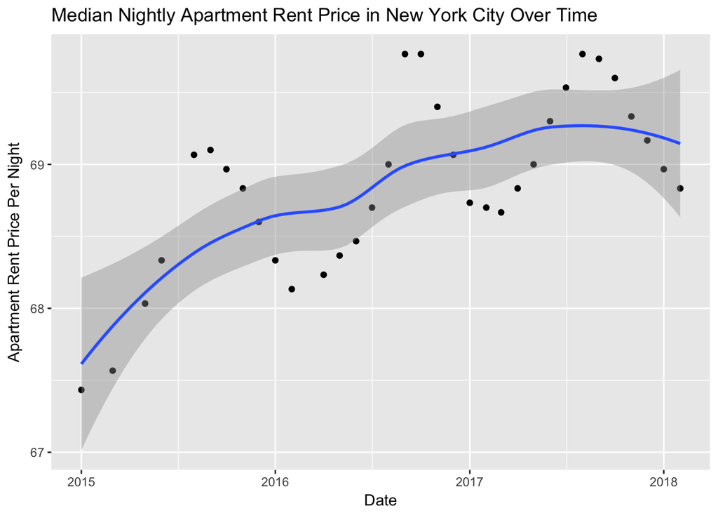

```r
library(tidyr)
library(ggplot2)

rent_plot <- final_df %>%
    ggplot(aes(x=Date,y=NightlyRentPrice)) +
    geom_point() +
    geom_smooth() +
    xlab("Date") +
    ylab("Apartment Rent Price Per Night") +
    ggtitle("Median Nightly Apartment Rent Price in New York City Over Time")

rent_plot
```

The rent plot shows a generally increasing trend in apartment rent prices. There are very noticeable spikes in prices during the middle of each year. According to [this Apartment Guide article](https://www.apartmentguide.com/blog/is-there-an-ideal-season-to-rent-an-apartment/), many Americans move between May and September of a given year. This is due to children getting out of school, college students graduating, and the better moving weather. So landlords can charge more during these months. The rent plot clearly shows this trend with the spikes in prices during the middle of the year.

Now let’s plot the Airbnb rent price vs the date.

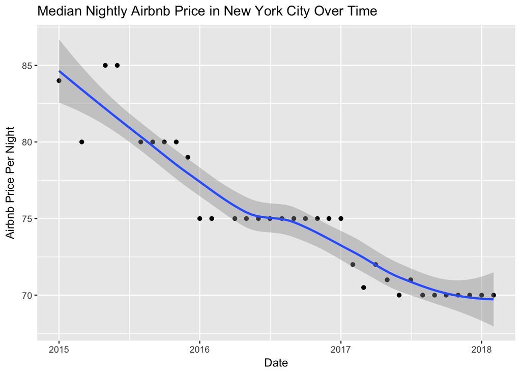

```r
library(tidyr)
library(ggplot2)

airbnb_plot <- final_df %>%
    ggplot(aes(x=Date,y=NightlyAirbnbPrice)) +
    geom_point() +
    geom_smooth() +
    xlab("Date") +
    ylab("Airbnb Price Per Night") +
    ggtitle("Median Nightly Airbnb Price in New York City Over Time")

airbnb_plot
```

The Airbnb median nightly rent price plot is very surprising to me. The plot shows a decreasing trend in prices over the years, but overall higher prices than apartments. However, for each year there are periods where the price plateaus and holds steady. For example, the second of half of 2015 has a steady price of $80 per night. For all of 2016, the median price is $75. For the second half of 2017, the price is $70 per night. The overall decrease in price could be due to the fact that Airbnb is growing. According to [this Recode article](https://www.recode.net/2017/7/19/15949782/airbnb-100-million-stays-2017-threat-business-hotel-industry), the number of travelers who used Airbnb in the last 12 months went from 12% in 2014 to an estimated 25% in 2017. Due to Airbnb’s growth and demand, there will be more listings which means more competition between listings to get customers. As the supply begans to reach the demand level, the prices become more competitive leading to lower prices. The plateaus could be due to same effects which cause mid-year spikes in prices for apartments. For the first half of the year, prices start fluctuating as people start looking for places to stay during the summer. Then prices steady after the summer, much like the return to beginning-of-the-year prices for apartments.

Now let’s graph the difference between the Airbnb price and apartment price. First, let’s create a new column for the differnce between the Airbnb and apartment price.

```r
diff_df <- final_df %>%
    mutate(diff = NightlyAirbnbPrice - NightlyRentPrice)

diff_df
```

```
## # A tibble: 34 x 4
##    Date       NightlyRentPrice NightlyAirbnbPrice  diff
##    <date>                <dbl>              <dbl> <dbl>
##  1 2015-01-01             67.4               84.0 16.6
##  2 2015-10-01             69.0               80.0 11.0
##  3 2015-11-01             68.8               80.0 11.2
##  4 2015-12-01             68.6               79.0 10.4
##  5 2015-03-01             67.6               80.0 12.4
##  6 2015-05-01             68.0               85.0 17.0
##  7 2015-06-01             68.3               85.0 16.7
##  8 2015-08-01             69.1               80.0 10.9
##  9 2015-09-01             69.1               80.0 10.9
## 10 2016-01-01             68.3               75.0  6.67
## # ... with 24 more rows
```

Let’s graph the differences over time.

[figure not shown]

```r
library(tidyr)
library(ggplot2)

diff_plot <- diff_df %>%
    ggplot(aes(x=Date,y=diff)) +
    geom_point() +
    geom_smooth() +
    xlab("Date") +
    ylab("Difference in Price Per Night") +
    ggtitle("Nightly Difference in Price for an Airbnb and Apartment Over Time")

diff_plot
```

The differences plot shows a decreasing trend over time. The differences between the Airbnb price and apartment price grows smaller over time. This leads me to believe that Airbnb has an influence on the apartment rent prices since the prices grow closer to each other (leading to smaller difference). However, one possibility to consider is the opposite effect - that Airbnb prices are getting lower over time closer to apartment rent prices. If apartment rent prices stay steady, but Airbnb prices decrease then the difference between the two would lower. This is the same difference if Airbnb stayed steady but apartment prices increased. For now I am going test if Airbnb has an effect on apartment prices.

As the data is recent, I do not feel there is a need to standardize or account for inflation.

## III. Hypothesis Testing and Machine Learning

We are going to test if Airbnb has an effect on apartment prices with hypothesis testing on the differences in the prices of Airbnb and apartments.

Our null hypothesis will be that Airbnb *does not* have an effect on apartment prices, so the difference in prices would be zero: $H_o = 0$. The alternative hypothesis will be that Airbnb *does* have an effect on apartment prices, so difference in prices would be positive: $H_a > 0$. We will be using the t-test to test our hypothesis. We are using the t-test because the population variance is unknown and the sample size is small. However, the t-test also assumes that the underlying variables come from a normal distribution. We can check by looking at the normal probabilty plot (NPP) and the reference line.

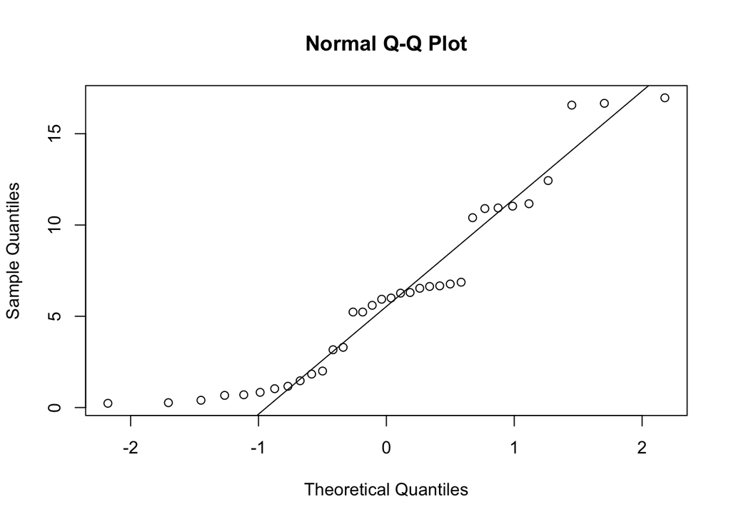

```r
qqnorm(diff_df$diff)
qqline(diff_df$diff)
```

```r
t_test <- t.test(diff_df$diff, alternative = "g")
t_test
```

```
##
##  One Sample t-test
##
## data:  diff_df$diff
## t = 7.2136, df = 33, p-value = 1.427e-08
## alternative hypothesis: true mean is greater than 0
## 95 percent confidence interval:
##  4.686163      Inf
## sample estimates:
## mean of x
##  6.122549
```

Since the p-value is less than 0.05, the null hypothesis is rejected. So we know that Airbnb has an effect on apartment prices as the alternative hypothesis was not rejected.

### Machine Learning

Now let’s attempt to come with a linear regression model for the relationship between apartment prices and Airbnb prices. We want to see the effect of Airbnb on apartment prices, so the relationship is modeled as such: $apt \ price = \beta_0 + \beta_1 * Airbnb \ price$. Since both variables are numeric and continous, and this is not a classification problem, we can use a linear regression model.

```r
library(broom)
library(knitr)

# bulid the linear model and pipe into the broom::tidy() function
price_model <- lm(NightlyRentPrice ~ NightlyAirbnbPrice, data = diff_df)
# broom::tidy() constructs a data frame that summarizes the model's statistical findings
price_model %>% tidy() %>% kable()
```

| term | estimate | std.error | statistic | p.value |
| --- | --- | --- | --- | --- |
| (Intercept) | 74.5137692 | 1.4047147 | 53.045483 | 0.0000000 |
| NightlyAirbnbPrice | -0.0753618 | 0.0186994 | -4.030175 | 0.0003217 |

Here are the mean prices of each type of room over the 3 years:

```r
paste("Mean nightly apartment rent price: ", mean(diff_df$NightlyRentPrice))
```

```
## [1] "Mean nightly apartment rent price:  68.8627450980392"
```

```r
paste("Mean nightly Airbnb price: ", mean(diff_df$NightlyAirbnbPrice))
```

```
## [1] "Mean nightly Airbnb price:  74.9852941176471"
```

Let’s also take a look at the fit of the model by calculating the $R^2$ measure based on the total sum of square and residual sum of squares.

```r
library(broom)
library(knitr)

# broom:glance() constructs a concise one-row summary of the model
price_model %>% glance() %>% kable()
```

| r.squared | adj.r.squared | sigma | statistic | p.value | df | logLik | AIC | BIC | deviance | df.residual |
| --- | --- | --- | --- | --- | --- | --- | --- | --- | --- | --- |
| 0.3366819 | 0.3159532 | 0.4919901 | 16.24231 | 0.0003217 | 2 | -23.0972 | 52.1944 | 56.77348 | 7.745735 | 32 |

Let’s check the residual plots to confirm the linearity (or lack thereof) of the relationship.

```r
library(broom)
library(knitr)

# broom::augment() adds predictions, residuals, and cluster assignments to original data that was modeled
aug_price_model <- price_model %>% augment()
aug_price_model %>% head() %>% kable()
```

| NightlyRentPrice | NightlyAirbnbPrice | .fitted | .se.fit | .resid | .hat | .sigma | .cooksd | .std.resid |
| --- | --- | --- | --- | --- | --- | --- | --- | --- |
| 67.43333 | 84 | 68.18338 | 0.1885070 | -0.7500476 | 0.1468055 | 0.4781134 | 0.2343587 | -1.6504732 |
| 68.96667 | 80 | 68.48483 | 0.1261444 | 0.4818387 | 0.0657390 | 0.4917785 | 0.0361200 | 1.0132374 |
| 68.83333 | 80 | 68.48483 | 0.1261444 | 0.3485053 | 0.0657390 | 0.4956499 | 0.0188957 | 0.7328566 |
| 68.60000 | 79 | 68.56019 | 0.1129386 | 0.0398102 | 0.0526953 | 0.4998084 | 0.0001922 | 0.0831368 |
| 67.56667 | 80 | 68.48483 | 0.1261444 | -0.9181613 | 0.0657390 | 0.4698454 | 0.1311542 | -1.9307612 |
| 68.03333 | 85 | 68.10802 | 0.2053992 | -0.0746859 | 0.1742950 | 0.4996444 | 0.0029456 | -0.1670589 |

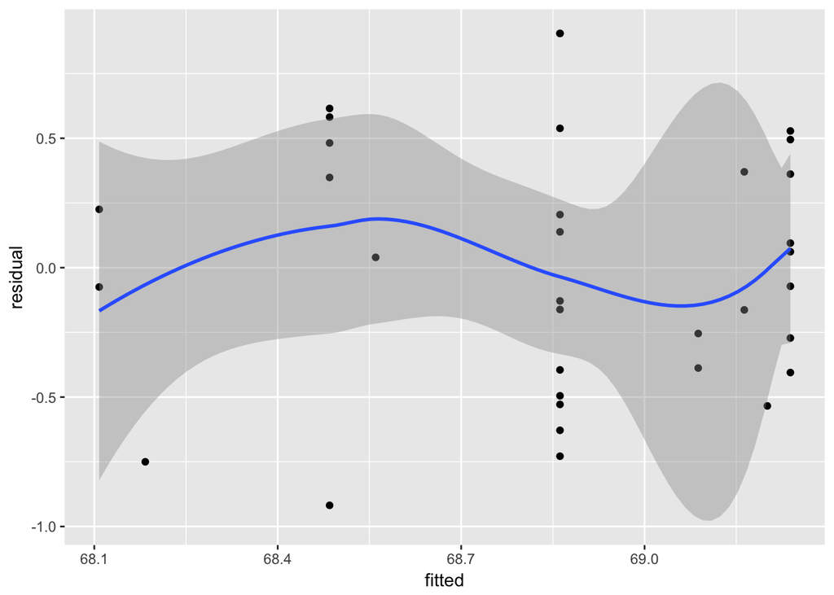

```r
resid_plot <- aug_price_model %>%
    ggplot(aes(x=.fitted, y=.resid)) +
    geom_point() +
    geom_smooth() +
    labs(x="fitted", y="residual")

resid_plot
```

As the residual plot shows, there is some non-linearity as indicated by the slight curves near the residual = 0 line. However, the there is no major clustering of points and very discernible patterns in the data. So a linear model is somewhat accurate in assessing the relationship between Airbnb price and apartment price.

## V. Further Reading

See these sources for further reading:

- [Airbnb is making rents in New York City spike as owners yank units off the market](https://www.cnbc.com/2018/01/31/airbnbn-pushing-up-new-york-rent-study-claims.html)
- [Housing Market Trends: How Airbnb Affects Home Prices and Rents](https://www.mashvisor.com/blog/how-airbnb-affects-home-prices-and-rents/)
- [There’s New Research Behind the Contention that Airbnb Raises Rents](https://www.citylab.com/equity/2017/08/where-airbnb-is-raising-rents/535674/)
- [How Airbnb Affects Home Prices and Rents](https://www.wsj.com/articles/how-airbnb-affects-home-prices-and-rents-1508724361)

### Sources

- Airbnb
- [Inside Airbnb](http://insideairbnb.com/get-the-data.html)
- [Apartment List](https://www.apartmentlist.com/rentonomics/rental-price-data/)
- [Recode](https://www.recode.net/2017/7/19/15949782/airbnb-100-million-stays-2017-threat-business-hotel-industry)
- [Apartment Guide](https://www.apartmentguide.com/blog/is-there-an-ideal-season-to-rent-an-apartment)
- [Tidyverse](https://www.tidyverse.org/)
- [Broom](https://cran.r-project.org/web/packages/broom/vignettes/broom.html)